# PPIP html report

2018-05-25

# Introduction

This report is designed to facilitate summarization and rapid browsing of complex results in PPIP pipelines.

# 1 QC

Quality control (QC) are necessary to facilitate successful genomics and proteomics analyses. This procedure will check the produced data to decide whether these are reliable enough to be used, and help to improve the arguments of tools in the Pipeline.

## 1.1 Quality control of NGS data

Quality control and filtering of sequencing reads is one of the most important steps in the pre-processing of sequencing reads. In this sub-section, the AfterQC (https://github.com/OpenGene/AfterQC), a tool with functions to profile sequencing errors and correct most of them, plus highly automated quality control and data filtering features will be used.

**Click me to view the QC report**

- 131012_I266_FCC2J5JACXX_L6_RSCOaowTAARAAPEI-72_1.fq.gz.html

## 1.2 Peptide-level qvalue distribution

This plot depicts the Q-value distribution of all PSMs (peptide spectrum match). In this pipeline, we used the Q-value <= 0.01 to find the truly significant results. The blue area is the density distribution of all Q-values. And the green curve represents the related empirical cumulative distribution of all Q-value.

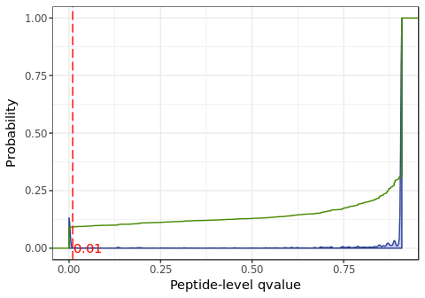

## 1.3 Precursor error distribution

This graph displays a precursor mass error distribution in MS-level. As shown in the figure, the blue curve represents the distribution of all the unfiltered PSMs. And the red curve indicates the trace of PSMs satisfied with statistical criteria.

[interactive chart not shown]

# 2 Basic result

The main purpose of this chapter is to describe the basic statistical analysis of endogenous peptides.

## 2.1 Identified peptide length distribution

Amino acid length distribution of the identified peptides.

[interactive chart not shown]

## 2.2 Spectral count of identified peptides

Spectral count, defined as the total number of spectra identified for a peptide, has gained acceptance as a practical in proteomic studies. As a supplement to Q-value, the more count a peptide has, the more credible the peptide is.

[interactive chart not shown]

## 2.3 Amino acid distribution of C-/N-term

To view the amino acid number distribution of N-terminus and C-terminus, we depict a barplot as follows:

[interactive chart not shown]

## 2.4 Cysteine distribution of peptides

During the maturation process of proteins in eukaryote, cysteine residues are oxidised and form disulfide bridges, which are important to maintain protein shapes. Through this shape, disulfide bonds play en essential role for the stability and the activity of proteins. The following graph use an pie to describe how many cysteine residues in each peptide.

[interactive chart not shown]

## 2.5 Summary table of peptides

This table includes the peptide identification result that could be used for further analysis.

| Peptide | Protein | PepQValue | SpecCount |
| --- | --- | --- | --- |
| AACYSSDCRVKCVAM | NTX178644 NTX178646 | 0.0 0.0 | 6 |
| AAGAGRFDPVSAAGAGR | NTX591829 NTX591831 NTX591832 | 0.0050167223 0.0050167223 0.0050167223 | 3 |
| ACWCEGLPAEKT | NTX262119 NTX262120 | 0.0 0.0 | 2 |
| ACWCEGLPDDKT | NTX41956 NTX41957 NTX41959 | 0.0 0.0 0.0 | 42 |
| ACWCIDLPDKVPIR | NTX602037 NTX602038 | 0.0 0.0 | 6 |
| ADGPTGTLQEIR | NTX178649 NTX623208 | 0.009661836 0.009661836 | 2 |
| ADGPTGTLQEIRKKWGA | NTX178649 NTX623208 | 0.0 0.0 | 2 |
| ADPAKNDDVEIVDHNFFRF | NTX144303 NTX144307 NTX144311 | 0.0 0.0 0.0 | 15 |
| AENLRYWNLITGLR | NTX334555 NTX334556 | 0.0 0.0 | 8 |
| AFDDSKRYDQRFAF | NTX163968 NTX163969 | 0.0 0.0 | 6 |
| AFGLGKRPDQRFSF | NTX496322 | 0.0 | 2 |
| AFIGAVAGLLSK | NTX372159 | 0.0 | 1 |
| AFQLPSHLDIRNPHTFEEEDL | NTX56407 | 0.0 | 1 |
| AILTPEVNKVYE | NTX56407 | 0.0 | 5 |
| AKNDDVEIVDHNFF | NTX144303 NTX144307 NTX144311 | 0.0 0.0 0.0 | 30 |
| AKNDDVEIVDHNFFRF | NTX144303 NTX144307 NTX144311 | 0.0 0.0 0.0 | 30 |
| ARNEYCNDLCTKNGAKSGYCQ | NTX49728 NTX49728 NTX49729 NTX49729 | 0.0 0.009661836 0.0 0.009661836 | 6 |
| ARSVLDDLNNQLDNLH | NTX428770 NTX428772 NTX428775 | 0.0 0.0 0.0 | 3 |
| ASYDFSSNDPFPYPR | NTX523065 NTX523066 | 0.0 0.0 | 6 |
| ATGGNRTKTPGPGAQSALRALAR | NTX519666 | 0.0 | 2 |
| ATKIIPSLFRR | NTX134676 | 0.0017064846 | 8 |
| ATVFYPSNCREEPGTGLYPDCCNKVVCGEEE | NTX83486 NTX83487 | 0.0 0.0 | 4 |
| AVSMDNCSRTGVCMNTCHENI | NTX213008 NTX213009 | 0.0 0.0 | 2 |
| CEGLPDNETWKYESNTCGS | NTX41958 NTX41960 | 0.0 0.0 | 2 |
| CGLGISCKNGYCQGCT | NTX371729 NTX371731 NTX371733 NTX483383 | 0.0 0.0 0.0 0.0 | 12 |
| CGPCFTTDANMAR | NTX312243 | 0.0 | 38 |
| CGPCFTTDANMARK | NTX312243 | 0.0 | 19 |
| CGPCFTTDANMARKC | NTX312243 | 0.0 | 8 |
| CIELPDNVPIRVPGKCH | NTX49728 NTX49729 | 0.0 0.0 | 20 |
| CIKYSWTCKFN | NTX154016 | 0.0 | 2 |

[output cut: 577 more lines]

Download the peptide summary

Furthermore, you can get more detailed PSM (peptide-spectrum match) information from the link below:

Download the PSM summary

# 3 Annotation

This chapter aims to explore the sequence motifs and potential function of the peptides via serveral different tools.

## 3.1 MSA

Multiple Sequence Alignment (MSA) is generally the alignment of three or more biological sequences (protein or nucleic acid) with similar length. From the output, homology can be inferred and the evolutionary relationships between the sequences cand be studied.

Click here to the multiple sequence alignment viewer

## 3.2 SignalP

The secretory signal peptide is a ubiquitous proteinsorting signal that targets its passenger protein for translocation across the endoplasmic reticulum membrane in eukaryotes and the cytoplasmic membrane in prokaryotes. In this section, the signalP 4.1 server, which is designed to discriminate between signal peptides and transmembrane regions, is utilized for predicting the presence and location of signal peptide cleavage sites in amino acid sequences from different organisms.

| ID | D | isSignal | Dmaxcut | Networks-used | Cmax | Ymax | Smax |
| --- | --- | --- | --- | --- | --- | --- | --- |
| NTX4281 | 0.104 | N | 0.45 | SignalP-noTM | 0.114 | 0.108 | 0.113 |
| NTX13418 | 0.889 | Y | 0.45 | SignalP-noTM | 0.803 | 0.857 | 0.96 |
| NTX14137 | 0.104 | N | 0.45 | SignalP-noTM | 0.108 | 0.106 | 0.118 |
| NTX24145 | 0.099 | N | 0.45 | SignalP-noTM | 0.114 | 0.104 | 0.109 |
| NTX28979 | 0.652 | Y | 0.45 | SignalP-noTM | 0.613 | 0.643 | 0.87 |
| NTX38478 | 0.103 | N | 0.45 | SignalP-noTM | 0.117 | 0.107 | 0.139 |
| NTX41956 | 0.12 | N | 0.45 | SignalP-noTM | 0.126 | 0.125 | 0.166 |
| NTX41957 | 0.127 | N | 0.45 | SignalP-noTM | 0.134 | 0.133 | 0.186 |
| NTX41958 | 0.122 | N | 0.45 | SignalP-noTM | 0.13 | 0.128 | 0.167 |
| NTX41959 | 0.127 | N | 0.45 | SignalP-noTM | 0.125 | 0.13 | 0.197 |
| NTX42998 | 0.113 | N | 0.45 | SignalP-noTM | 0.133 | 0.119 | 0.133 |
| NTX43000 | 0.124 | N | 0.45 | SignalP-noTM | 0.172 | 0.139 | 0.159 |
| NTX49728 | 0.101 | N | 0.45 | SignalP-noTM | 0.11 | 0.105 | 0.109 |
| NTX51254 | 0.331 | N | 0.5 | SignalP-TM | 0.445 | 0.407 | 0.647 |
| NTX56407 | 0.103 | N | 0.45 | SignalP-noTM | 0.109 | 0.107 | 0.115 |
| NTX83486 | 0.312 | N | 0.5 | SignalP-TM | 0.588 | 0.343 | 0.468 |
| NTX83904 | 0.432 | N | 0.5 | SignalP-TM | 0.268 | 0.405 | 0.771 |
| NTX83905 | 0.427 | N | 0.5 | SignalP-TM | 0.284 | 0.403 | 0.729 |
| NTX85997 | 0.287 | N | 0.5 | SignalP-TM | 0.213 | 0.28 | 0.685 |
| NTX91175 | 0.274 | N | 0.5 | SignalP-TM | 0.297 | 0.272 | 0.401 |
| NTX91255 | 0.102 | N | 0.45 | SignalP-noTM | 0.131 | 0.112 | 0.123 |
| NTX94322 | 0.698 | Y | 0.45 | SignalP-noTM | 0.555 | 0.643 | 0.859 |
| NTX98053 | 0.101 | N | 0.45 | SignalP-noTM | 0.111 | 0.104 | 0.166 |
| NTX102642 | 0.099 | N | 0.45 | SignalP-noTM | 0.107 | 0.103 | 0.144 |
| NTX104669 | 0.552 | Y | 0.5 | SignalP-TM | 0.678 | 0.629 | 0.86 |
| NTX112170 | 0.171 | N | 0.5 | SignalP-TM | 0.262 | 0.185 | 0.29 |
| NTX132748 | 0.099 | N | 0.45 | SignalP-noTM | 0.11 | 0.103 | 0.108 |
| NTX132749 | 0.099 | N | 0.45 | SignalP-noTM | 0.11 | 0.103 | 0.108 |
| NTX134676 | 0.252 | N | 0.5 | SignalP-TM | 0.458 | 0.308 | 0.394 |
| NTX134688 | 0.102 | N | 0.45 | SignalP-noTM | 0.106 | 0.107 | 0.123 |

[output cut: 128 more lines]

## 3.3 Venom annotation

Venoms are substances that are secreted by animals for either defensive or offensive purposes and that have a toxic or harmful effect on other animals. We annotated the endogenous peptides with an open-source and publicly accessible resource for researchers and other individuals interested in venom therapeutics (VenomKB,http://venomkb.org). In the following table,the venom entry related with an endogenous peptide will be merged into one group for presentation.

| Venomkb_id | Percentage_identical | Expect_value | Venom_name | Venomkb_link |
| --- | --- | --- | --- | --- |
| **NTX14137** |  |  |  |  |
| P4592344 | 100 | 0.0e+00 | BmK-YA precursor | http://venomkb.org/P4592344 |
| P4592344 | 97.619 | 0.0e+00 | BmK-YA precursor | http://venomkb.org/P4592344 |
| P4592344 | 97.619 | 0.0e+00 | BmK-YA precursor | http://venomkb.org/P4592344 |
| P4592344 | 95.238 | 0.0e+00 | BmK-YA precursor | http://venomkb.org/P4592344 |
| P4592344 | 95.238 | 0.0e+00 | BmK-YA precursor | http://venomkb.org/P4592344 |
| P4592344 | 95.238 | 0.0e+00 | BmK-YA precursor | http://venomkb.org/P4592344 |
| P4592344 | 92.857 | 0.0e+00 | BmK-YA precursor | http://venomkb.org/P4592344 |
| P4592344 | 82.759 | 0.0e+00 | BmK-YA precursor | http://venomkb.org/P4592344 |
| **NTX41956** |  |  |  |  |
| P4943114 | 91.379 | 0.0e+00 | Toxin BmKITc | http://venomkb.org/P4943114 |
| P3077021 | 86.207 | 0.0e+00 | Anti-neuroexcitation peptide 2 | http://venomkb.org/P3077021 |
| P7736827 | 85.965 | 0.0e+00 | Beta-insect depressant toxin LqhIT2 | http://venomkb.org/P7736827 |
| P1990136 | 85.965 | 0.0e+00 | Insect toxin 2-53 | http://venomkb.org/P1990136 |
| P2415271 | 82.759 | 0.0e+00 | Beta-insect depressant toxin BmKITa | http://venomkb.org/P2415271 |
| P8255564 | 84.483 | 0.0e+00 | Neurotoxin BmKAEP2 | http://venomkb.org/P8255564 |
| P3706610 | 84.483 | 0.0e+00 | Depressant insect toxin BmK ITa1 | http://venomkb.org/P3706610 |
| P5127212 | 82.759 | 0.0e+00 | Beta-insect depressant toxin BmKITb | http://venomkb.org/P5127212 |
| P0314897 | 82.759 | 0.0e+00 | Anti-neuroexcitation peptide 3 | http://venomkb.org/P0314897 |
| P1446795 | 82.759 | 0.0e+00 | Depressant scorpion toxin BmKIM | http://venomkb.org/P1446795 |
| P0517870 | 82.759 | 0.0e+00 | Toxin BmKIT3 | http://venomkb.org/P0517870 |
| P7331272 | 85.455 | 0.0e+00 | Beta-insect depressant toxin BotIT4 | http://venomkb.org/P7331272 |
| P2906605 | 85.455 | 0.0e+00 | Beta-insect depressant toxin BaIT2 | http://venomkb.org/P2906605 |
| P2923788 | 85.455 | 0.0e+00 | Beta-insect depressant toxin BotIT5 | http://venomkb.org/P2923788 |
| P4338962 | 83.333 | 0.0e+00 | Beta-insect depressant toxin LqqIT2 | http://venomkb.org/P4338962 |
| P6179056 | 81.034 | 0.0e+00 | Beta-insect depressant toxin BmKIT4 | http://venomkb.org/P6179056 |
| **NTX41957** |  |  |  |  |
| P2415271 | 96.552 | 0.0e+00 | Beta-insect depressant toxin BmKITa | http://venomkb.org/P2415271 |
| P3077021 | 96.552 | 0.0e+00 | Anti-neuroexcitation peptide 2 | http://venomkb.org/P3077021 |
| P3706610 | 96.552 | 0.0e+00 | Depressant insect toxin BmK ITa1 | http://venomkb.org/P3706610 |

[output cut: 187 more lines]

Download the venom annotation file

## 3.4 Functional annotation

Gene ontology (GO) is one the fundamental functional classification system. In this sub-section, it was applied to annotate the peptides and illustrated as a treemap below:

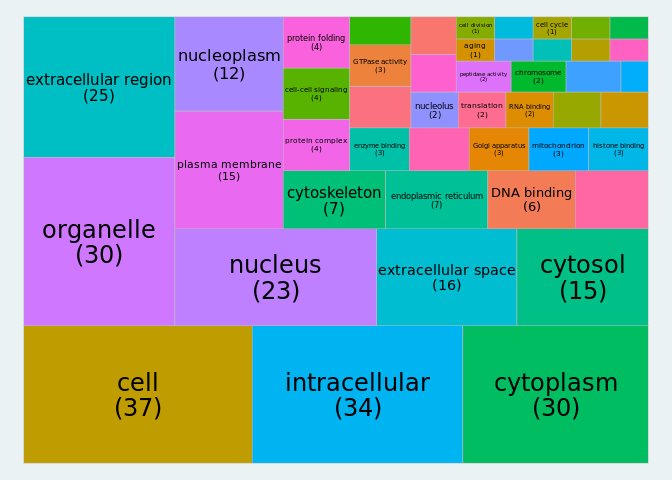

Download the gene ontology summary

A biological pathway is a series of interactions among molecules in a cell that leads to a certain product or a change in a cell. Such a pathway can trigger the assembly of new molecules, such as a fat or protein. Pathways can also turn genes on and off, or spur a cell to move. In the table below, all of the items with availbale pathway annotation were listed.

| ID | GeneID | GeneName | Hyperlink |
| --- | --- | --- | --- |
| NTX4281 | hsa:55207 | ARL8B ARL10C Gie1 | http://www.genome.jp/dbget-bin/www_bget?hsa:55207 |
| NTX13418 | hsa:2195 | FAT1 CDHF7 CDHR8 FAT ME5 hFat1 | http://www.genome.jp/dbget-bin/www_bget?hsa:2195 |
| NTX24145 | hsa:70 | ACTC1 ACTC ASD5 CMD1R CMH11 LVNC4 | http://www.genome.jp/dbget-bin/www_bget?hsa:70 |
| NTX38478 | hsa:71 | ACTG1 ACT ACTG BRWS2 DFNA20 DFNA26 HEL-176 | http://www.genome.jp/dbget-bin/www_bget?hsa:71 |
| NTX56407 | hsa:4925 | NUCB2 HEL-S-109 NEFA | http://www.genome.jp/dbget-bin/www_bget?hsa:4925 |
| NTX94322 | hsa:3309 | HSPA5 BIP GRP78 HEL-S-89n MIF2 | http://www.genome.jp/dbget-bin/www_bget?hsa:3309 |
| NTX102642 | hsa:71 | ACTG1 ACT ACTG BRWS2 DFNA20 DFNA26 HEL-176 | http://www.genome.jp/dbget-bin/www_bget?hsa:71 |
| NTX132748 | hsa:554313 | HIST2H4B H4/o | http://www.genome.jp/dbget-bin/www_bget?hsa:554313 |
| NTX132749 | hsa:554313 | HIST2H4B H4/o | http://www.genome.jp/dbget-bin/www_bget?hsa:554313 |
| NTX136251 | hsa:102 | ADAM10 AD10 AD18 CD156c CDw156 HsT18717 MADM RAK kuz | http://www.genome.jp/dbget-bin/www_bget?hsa:102 |
| NTX142744 | hsa:5648 | MASP1 3MC1 CRARF CRARF1 MAP1 MASP MASP3 MAp44 PRSS5 RaRF | http://www.genome.jp/dbget-bin/www_bget?hsa:5648 |
| NTX148639 | hsa:60 | ACTB BRWS1 PS1TP5BP1 | http://www.genome.jp/dbget-bin/www_bget?hsa:60 |
| NTX173892 | hsa:71 | ACTG1 ACT ACTG BRWS2 DFNA20 DFNA26 HEL-176 | http://www.genome.jp/dbget-bin/www_bget?hsa:71 |
| NTX177486 | hsa:11093 | ADAMTS13 ADAM-TS13 ADAMTS-13 C9orf8 VWFCP vWF-CP | http://www.genome.jp/dbget-bin/www_bget?hsa:11093 |
| NTX178649 | hsa:90411 | MCFD2 F5F8D F5F8D2 LMAN1IP SDNSF | http://www.genome.jp/dbget-bin/www_bget?hsa:90411 |
| NTX186740 | hsa:7170 | TPM3 CAPM1 CFTD HEL-189 HEL-S-82p NEM1 OK/SW-cl.5 TM-5 TM3 TM30 TM30nm TM5 TPMsk3 TRK hscp30 | http://www.genome.jp/dbget-bin/www_bget?hsa:7170 |
| NTX189949 | hsa:726 | CAPN5 ADNIV HTRA3 VRNI nCL-3 | http://www.genome.jp/dbget-bin/www_bget?hsa:726 |
| NTX212167 | hsa:51121 | RPL26L1 RPL26P1 | http://www.genome.jp/dbget-bin/www_bget?hsa:51121 |
| NTX213988 | hsa:653604 | HIST2H3D | http://www.genome.jp/dbget-bin/www_bget?hsa:653604 |
| NTX214579 | hsa:347733 | TUBB2B PMGYSA bA506K6.1 | http://www.genome.jp/dbget-bin/www_bget?hsa:347733 |
| NTX226741 | hsa:8340 | HIST1H2BL H2B/c H2BFC dJ97D16.4 | http://www.genome.jp/dbget-bin/www_bget?hsa:8340 |
| NTX227449 | hsa:6189 | RPS3A FTE1 MFTL S3A | http://www.genome.jp/dbget-bin/www_bget?hsa:6189 |
| NTX235909 | hsa:5034 | P4HB CLCRP1 DSI ERBA2L GIT P4Hbeta PDI PDIA1 PHDB PO4DB PO4HB PROHB | http://www.genome.jp/dbget-bin/www_bget?hsa:5034 |
| NTX235912 | hsa:5034 | P4HB CLCRP1 DSI ERBA2L GIT P4Hbeta PDI PDIA1 PHDB PO4DB PO4HB PROHB | http://www.genome.jp/dbget-bin/www_bget?hsa:5034 |
| NTX248037 | hsa:805 | CALM2 CAMII LQT15 PHKD PHKD2 caM | http://www.genome.jp/dbget-bin/www_bget?hsa:805 |
| NTX258811 | hsa:60 | ACTB BRWS1 PS1TP5BP1 | http://www.genome.jp/dbget-bin/www_bget?hsa:60 |
| NTX260492 | hsa:1506 | CTRL CTRL1 | http://www.genome.jp/dbget-bin/www_bget?hsa:1506 |
| NTX270040 | hsa:2597 | GAPDH G3PD GAPD HEL-S-162eP | http://www.genome.jp/dbget-bin/www_bget?hsa:2597 |
| NTX283712 | hsa:3854 | KRT6B CK-6B CK6B K6B KRTL1 PC2 PC4 | http://www.genome.jp/dbget-bin/www_bget?hsa:3854 |
| NTX317140 | hsa:5651 | TMPRSS15 ENTK PRSS7 | http://www.genome.jp/dbget-bin/www_bget?hsa:5651 |
| NTX324164 | hsa:10383 | TUBB4B Beta2 TUBB2 TUBB2C | http://www.genome.jp/dbget-bin/www_bget?hsa:10383 |
| NTX334429 | hsa:5986 | RFNG | http://www.genome.jp/dbget-bin/www_bget?hsa:5986 |
| NTX335822 | hsa:3998 | LMAN1 ERGIC-53 ERGIC53 F5F8D FMFD1 MCFD1 MR60 gp58 | http://www.genome.jp/dbget-bin/www_bget?hsa:3998 |
| NTX336196 | hsa:8345 | HIST1H2BH H2B/j H2BFJ | http://www.genome.jp/dbget-bin/www_bget?hsa:8345 |
| NTX352134 | hsa:8708 | B3GALT1 beta3Gal-T1 | http://www.genome.jp/dbget-bin/www_bget?hsa:8708 |
| NTX361043 | hsa:5651 | TMPRSS15 ENTK PRSS7 | http://www.genome.jp/dbget-bin/www_bget?hsa:5651 |
| NTX430388 | hsa:5110 | PCMT1 PIMT | http://www.genome.jp/dbget-bin/www_bget?hsa:5110 |
| NTX431293 | hsa:7178 | TPT1 HRF TCTP p02 p23 | http://www.genome.jp/dbget-bin/www_bget?hsa:7178 |
| NTX438454 | hsa:140606 | SELM SEPM | http://www.genome.jp/dbget-bin/www_bget?hsa:140606 |
| NTX465514 | hsa:3856 | KRT8 CARD2 CK-8 CK8 CYK8 K2C8 K8 KO | http://www.genome.jp/dbget-bin/www_bget?hsa:3856 |
| NTX468692 | hsa:10975 | UQCR11 0710008D09Rik QCR10 UQCR | http://www.genome.jp/dbget-bin/www_bget?hsa:10975 |
| NTX487637 | hsa:5122 | PCSK1 BMIQ12 NEC1 PC1 PC3 SPC3 | http://www.genome.jp/dbget-bin/www_bget?hsa:5122 |
| NTX487647 | hsa:5122 | PCSK1 BMIQ12 NEC1 PC1 PC3 SPC3 | http://www.genome.jp/dbget-bin/www_bget?hsa:5122 |
| NTX494486 | hsa:170692 | ADAMTS18 ADAMTS21 KNO2 MMCAT | http://www.genome.jp/dbget-bin/www_bget?hsa:170692 |
| NTX519666 | hsa:6208 | RPS14 EMTB S14 | http://www.genome.jp/dbget-bin/www_bget?hsa:6208 |
| NTX523065 | hsa:5126 | PCSK2 NEC_2 NEC-2 NEC2 PC2 SPC2 | http://www.genome.jp/dbget-bin/www_bget?hsa:5126 |
| NTX541125 | hsa:59084 | ENPP5 NPP-5 | http://www.genome.jp/dbget-bin/www_bget?hsa:59084 |
| NTX546099 | hsa:5045 | FURIN FUR PACE PCSK3 SPC1 | http://www.genome.jp/dbget-bin/www_bget?hsa:5045 |
| NTX558144 | hsa:4697 | NDUFA4 CI-9k CI-MLRQ MLRQ | http://www.genome.jp/dbget-bin/www_bget?hsa:4697 |
| NTX577282 | hsa:3856 | KRT8 CARD2 CK-8 CK8 CYK8 K2C8 K8 KO | http://www.genome.jp/dbget-bin/www_bget?hsa:3856 |
| NTX584753 | hsa:5651 | TMPRSS15 ENTK PRSS7 | http://www.genome.jp/dbget-bin/www_bget?hsa:5651 |
| NTX629813 | hsa:23071 | ERP44 PDIA10 TXNDC4 | http://www.genome.jp/dbget-bin/www_bget?hsa:23071 |
| NTX644816 | hsa:50487 | PLA2G3 GIII-SPLA2 SPLA2III sPLA2-III | http://www.genome.jp/dbget-bin/www_bget?hsa:50487 |
| NTX644817 | hsa:50487 | PLA2G3 GIII-SPLA2 SPLA2III sPLA2-III | http://www.genome.jp/dbget-bin/www_bget?hsa:50487 |

Download the pathway summary

## 3.4 Similarity search

A BLAST search allows users to infer the function of a sequence from similar sequences. A tab-delimited table is available from the link below.

Download the tabular table of BLAST

Besides, this tool also provides a graphic summary and some description for each alignment between the query sequence and the sequence hits from the database.

**Click me to view the detail**

- NTX213008.html
- NTX154016.html
- NTX91255.html
- NTX83904.html
- NTX224662.html
- NTX592223.html
- NTX258811.html
- NTX201404.html
- NTX644816.html
- NTX361043.html
- NTX591828.html
- NTX4281.html
- NTX311249.html
- NTX374064.html
- NTX378014.html
- NTX163969.html
- NTX372384.html
- NTX428770.html
- NTX214579.html
- NTX186740.html
- NTX485684.html
- NTX352134.html
- NTX434966.html
- NTX629813.html
- NTX41956.html
- NTX323335.html
- NTX178649.html
- NTX416169.html
- NTX359850.html
- NTX249700.html
- NTX462752.html
- NTX112170.html
- NTX374058.html
- NTX98053.html
- NTX317140.html
- NTX224320.html
- NTX416183.html
- NTX384939.html
- NTX235909.html
- NTX644817.html
- NTX248037.html
- NTX173892.html
- NTX407408.html
- NTX132748.html
- NTX14137.html
- NTX135011.html
- NTX262119.html
- NTX597930.html
- NTX374059.html
- NTX41959.html
- NTX372159.html
- NTX637329.html
- NTX260492.html
- NTX134676.html
- NTX142744.html
- NTX487647.html
- NTX496574.html
- NTX177808.html
- NTX189949.html
- NTX627879.html
- NTX602038.html
- NTX135801.html
- NTX227449.html
- NTX226741.html
- NTX91175.html
- NTX163968.html
- NTX132749.html
- NTX565257.html
- NTX494486.html
- NTX584753.html
- NTX177486.html
- NTX311050.html
- NTX181117.html
- NTX519666.html
- NTX384947.html
- NTX591829.html
- NTX283712.html
- NTX581382.html
- NTX487637.html
- NTX430388.html
- NTX496567.html
- NTX413483.html
- NTX271896.html
- NTX212167.html
- NTX612360.html
- NTX49728.html
- NTX577282.html
- NTX335822.html
- NTX465514.html
- NTX431293.html
- NTX558144.html
- NTX223142.html
- NTX213988.html
- NTX468692.html
- NTX602037.html
- NTX24145.html
- NTX249702.html
- NTX102642.html
- NTX41958.html
- NTX270040.html
- NTX83905.html
- NTX374070.html
- NTX371729.html
- NTX56407.html
- NTX287294.html
- NTX144303.html
- NTX51254.html
- NTX104669.html
- NTX94322.html
- NTX85997.html
- NTX164951.html
- NTX546099.html
- NTX374060.html
- NTX334555.html
- NTX336196.html
- NTX444153.html
- NTX660903.html
- NTX385699.html
- NTX235912.html
- NTX43000.html
- NTX549633.html
- NTX523065.html
- NTX134688.html
- NTX479826.html
- NTX512262.html
- NTX496322.html
- NTX334743.html
- NTX148639.html
- NTX423614.html
- NTX311250.html
- NTX624266.html
- NTX334429.html
- NTX596227.html
- NTX438454.html
- NTX662347.html
- NTX365400.html
- NTX41957.html
- NTX315967.html
- NTX541125.html
- NTX583217.html
- NTX312243.html
- NTX136251.html
- NTX178644.html
- NTX333875.html
- NTX38478.html
- NTX373661.html
- NTX574605.html
- NTX485692.html
- NTX324164.html
- NTX28979.html
- NTX13418.html
- NTX42998.html
- NTX366384.html
- NTX479827.html
- NTX305063.html
- NTX83486.html
- NTX218921.html
- NTX374063.html